# R Deep Neural Net Work

##Deep Learning with Keras & TensorFlow #Install Packages

```r
library(keras)
#install_keras()
```

#CTG <- read.csv(“C:/Users/17875/Downloads/CTG.csv”, header = TRUE) #Read the data

```r
data <- read.csv(file.choose(), header = T) #CTG <- read.csv("C:/Users/17875/Downloads/CTG.csv", header = TRUE)
str(data)
```

```
'data.frame':   2126 obs. of  22 variables:
 $ LB      : int  120 132 133 134 132 134 134 122 122 122 ...
 $ AC      : num  0 0.00638 0.00332 0.00256 0.00651 ...
 $ FM      : num  0 0 0 0 0 0 0 0 0 0 ...
 $ UC      : num  0 0.00638 0.00831 0.00768 0.00814 ...
 $ DL      : num  0 0.00319 0.00332 0.00256 0 ...
 $ DS      : num  0 0 0 0 0 0 0 0 0 0 ...
 $ DP      : num  0 0 0 0 0 ...
 $ ASTV    : int  73 17 16 16 16 26 29 83 84 86 ...
 $ MSTV    : num  0.5 2.1 2.1 2.4 2.4 5.9 6.3 0.5 0.5 0.3 ...
 $ ALTV    : int  43 0 0 0 0 0 0 6 5 6 ...
 $ MLTV    : num  2.4 10.4 13.4 23 19.9 0 0 15.6 13.6 10.6 ...
 $ Width   : int  64 130 130 117 117 150 150 68 68 68 ...
 $ Min     : int  62 68 68 53 53 50 50 62 62 62 ...
 $ Max     : int  126 198 198 170 170 200 200 130 130 130 ...
 $ Nmax    : int  2 6 5 11 9 5 6 0 0 1 ...
 $ Nzeros  : int  0 1 1 0 0 3 3 0 0 0 ...
 $ Mode    : int  120 141 141 137 137 76 71 122 122 122 ...
 $ Mean    : int  137 136 135 134 136 107 107 122 122 122 ...
 $ Median  : int  121 140 138 137 138 107 106 123 123 123 ...
 $ Variance: int  73 12 13 13 11 170 215 3 3 1 ...
 $ Tendency: int  1 0 0 1 1 0 0 1 1 1 ...
 $ NSP     : int  2 1 1 1 1 3 3 3 3 3 ...
```

#Change to Matrix

```r
data <- as.matrix(data)
dimnames(data) <- NULL
```

#Normalize

```r
data[,1:21] <- normalize(data[,1:21])
```

```
2021-05-04 17:59:53.278393: W tensorflow/stream_executor/platform/default/dso_loader.cc:60] Could not load dynamic library 'cudart64_110.dll'; dlerror: cudart64_110.dll not found
2021-05-04 17:59:53.444884: I tensorflow/stream_executor/cuda/cudart_stub.cc:29] Ignore above cudart dlerror if you do not have a GPU set up on your machine.
```

```r
data[,22] <- as.numeric(data[,22])-1
summary(data)
```

```
       V1               V2                  V3                  V4
 Min.   :0.2894   Min.   :0.000e+00   Min.   :0.000e+00   Min.   :0.000e+00
 1st Qu.:0.3747   1st Qu.:0.000e+00   1st Qu.:0.000e+00   1st Qu.:5.398e-06
 Median :0.3862   Median :4.572e-06   Median :0.000e+00   Median :1.286e-05
 Mean   :0.3833   Mean   :8.915e-06   Mean   :2.721e-05   Mean   :1.264e-05
 3rd Qu.:0.3949   3rd Qu.:1.596e-05   3rd Qu.:7.171e-06   3rd Qu.:1.900e-05
 Max.   :0.4537   Max.   :5.983e-05   Max.   :1.446e-03   Max.   :4.244e-05
       V5                  V6                  V7                  V8
 Min.   :0.000e+00   Min.   :0.000e+00   Min.   :0.000e+00   Min.   :0.03438
 1st Qu.:0.000e+00   1st Qu.:0.000e+00   1st Qu.:0.000e+00   1st Qu.:0.09199
 Median :0.000e+00   Median :0.000e+00   Median :0.000e+00   Median :0.13506
 Mean   :5.560e-06   Mean   :1.208e-08   Mean   :4.733e-07   Mean   :0.13498
 3rd Qu.:9.478e-06   3rd Qu.:0.000e+00   3rd Qu.:0.000e+00   3rd Qu.:0.17348
 Max.   :4.997e-05   Max.   :4.821e-06   Max.   :1.734e-05   Max.   :0.28247
       V9                 V10               V11               V12                V13
 Min.   :0.0005181   Min.   :0.00000   Min.   :0.00000   Min.   :0.008531   Min.   :0.1171
 1st Qu.:0.0019697   1st Qu.:0.00000   1st Qu.:0.01276   1st Qu.:0.106336   1st Qu.:0.1929
 Median :0.0033797   Median :0.00000   Median :0.02114   Median :0.197361   Median :0.2762
 Mean   :0.0038681   Mean   :0.02772   Mean   :0.02370   Mean   :0.202034   Mean   :0.2689
 3rd Qu.:0.0051435   3rd Qu.:0.03180   3rd Qu.:0.03173   3rd Qu.:0.291810   3rd Qu.:0.3454
 Max.   :0.0193124   Max.   :0.27950   Max.   :0.13866   Max.   :0.482050   Max.   :0.3926
      V14              V15               V16                 V17              V18
 Min.   :0.3867   Min.   :0.00000   Min.   :0.0000000   Min.   :0.1405   Min.   :0.1929
 1st Qu.:0.4462   1st Qu.:0.00537   1st Qu.:0.0000000   1st Qu.:0.3895   1st Qu.:0.3813
 Median :0.4673   Median :0.01011   Median :0.0000000   Median :0.4017   Median :0.3968
 Mean   :0.4709   Mean   :0.01166   Mean   :0.0009312   Mean   :0.3942   Mean   :0.3862
 3rd Qu.:0.4914   3rd Qu.:0.01705   3rd Qu.:0.0000000   3rd Qu.:0.4093   3rd Qu.:0.4035
 Max.   :0.6333   Max.   :0.05029   Max.   :0.0246323   Max.   :0.4495   Max.   :0.4364
      V19              V20                V21                  V22
 Min.   :0.2321   Min.   :0.000000   Min.   :-0.0035625   Min.   :0.0000
 1st Qu.:0.3913   1st Qu.:0.005879   1st Qu.: 0.0000000   1st Qu.:0.0000
 Median :0.4037   Median :0.020913   Median : 0.0000000   Median :0.0000
 Mean   :0.3961   Mean   :0.053473   Mean   : 0.0009039   Mean   :0.3043
 3rd Qu.:0.4094   3rd Qu.:0.068854   3rd Qu.: 0.0027577   3rd Qu.:0.0000
 Max.   :0.4303   Max.   :0.655737   Max.   : 0.0035719   Max.   :2.0000
```

#Data Partition

```r
set.seed(123)
ind <- sample(2, nrow(data), replace = T, prob = c(0.7, 0.3))
training <- data[ind==1, 1:21]
test <- data[ind==2, 1:21]
trainingtarget <- data[ind==1,22]
testtarget <- data[ind==2,22]
```

#One Hot Encoding #Creating this dummy variables for categories

```r
trainLabels <- to_categorical(trainingtarget)
testLabels <- to_categorical(testtarget)
print(testLabels)
```

```
       [,1] [,2] [,3]
  [1,]    1    0    0
  [2,]    1    0    0
  [3,]    1    0    0
  [4,]    0    0    1
  [5,]    0    1    0
  [6,]    1    0    0
  [7,]    1    0    0
  [8,]    0    0    1
  [9,]    0    0    1
 [10,]    0    0    1
 [11,]    1    0    0
 [12,]    1    0    0
 [13,]    1    0    0
 [14,]    1    0    0
```

[output cut: 320 more lines]

#Create Sequential model

```r
model <- keras_model_sequential()
```

[output not shown]

```r
model %>%
  layer_dense(units = 8, activation = 'relu', input_shape = c(21)) %>% #relu = Rectified                                                                            Linear Units
  layer_dense(units = 3, activation = 'softmax') #softmax activation function in the output
summary(model)                                    #layer help to keep range between o, & 1                                                      which can be used as probabilities
```

```
Model: "sequential"
______________________________________________________________________________________________
Layer (type)                              Output Shape                         Param #
==============================================================================================
dense_1 (Dense)                           (None, 8)                            176
______________________________________________________________________________________________
dense (Dense)                             (None, 3)                            27
==============================================================================================
Total params: 203
Trainable params: 203
Non-trainable params: 0
______________________________________________________________________________________________
```

#21independent variables 21 *8 = 168 + 8 constant values = 176 #3 nodes 8* 3 = 24 + 3 = 27

#Compile the model

```r
model %>%                   #this is because we have three categories
  compile(loss = 'categorical_crossentropy',  #For two categories we can use 'binary_crossentropy loss function used for two category situations
          optimizer = 'adam',           #Adam optimization algorithm is a popular algorithm in deep learning field
          metrics = 'accuracy')
```

#Fit Model (Multilayer Perceptron Neural Network for Multi-class Softmax classification)

```r
history <- model %>%
  fit(training, trainLabels,
      epoch = 200,     #how many times we run this model
      batch_size = 32,   # number of samples thata we used for gradients
      validation_split = 0.2)
```

```
2021-05-04 18:03:57.217984: I tensorflow/compiler/mlir/mlir_graph_optimization_pass.cc:116] None of the MLIR optimization passes are enabled (registered 2)
```

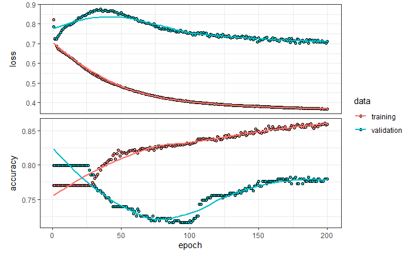

```r
plot(history)
```

```r
head(history)
```

#Evaluate Model - Test Data

```r
model1 <- model %>%
  evaluate(test, testLabels)
```

#Prediction & confusion Matrix - test data

```r
prob <- model %>%
  predict_proba(test)
```

Predict

```r
pred <- model %>%
  predict_classes(test)
table1 <- table(Predicted = pred, Actual = testtarget)
table1
```

```
         Actual
Predicted   0   1   2
        0 465  36  20
        1  26  46  12
        2   4   0  22
```

```r
DNnCatcr_200R <- table1
DNnCatcr_200R <- as.data.frame(DNnCatcr_200R)
DNnCatcr_200R <- mutate(DNnCatcr_200R, tab = "DNnCC")
DNnCatcr_200R
```

[output not shown]

```r
write.csv(DNnCatcr_200R, "DNnCatcr_200R.csv")
```

```r
cbind(prob, pred, testtarget)
```

```
                                             pred testtarget
  [1,] 0.9854537249 0.014263962 2.823285e-04    0          0
  [2,] 0.9863551259 0.013457596 1.873480e-04    0          0
  [3,] 0.9870820045 0.012744732 1.732538e-04    0          0
  [4,] 0.1609783173 0.673395932 1.656258e-01    1          2
  [5,] 0.8780987263 0.114671402 7.229917e-03    0          1
  [6,] 0.9724184871 0.026376508 1.205045e-03    0          0
  [7,] 0.9631910324 0.035224266 1.584606e-03    0          0
  [8,] 0.4659841657 0.208604842 3.254110e-01    0          2
  [9,] 0.2050952762 0.692363977 1.025408e-01    1          2
 [10,] 0.0009598499 0.228764728 7.702754e-01    2          2
 [11,] 0.9393507838 0.054016609 6.632634e-03    0          0
 [12,] 0.9270483255 0.060801599 1.215007e-02    0          0
 [13,] 0.9652029872 0.033381067 1.415895e-03    0          0
 [14,] 0.9728576541 0.026135048 1.007362e-03    0          0
```

[output cut: 187 more lines]

#Fine Tune Model

```r
table1
```

```
         Actual
Predicted   0   1   2
        0 465  36  20
        1  26  46  12
        2   4   0  22
```

```r
model1
```

```
     loss  accuracy
0.4225398 0.8446910
```

#Create Sequential model2

```r
model <- keras_model_sequential()
model %>%
  layer_dense(units = 50, activation = 'relu', input_shape = c(21)) %>% #relu = Rectified                                                                            Linear Units
  layer_dense(units = 3, activation = 'softmax') #softmax activation function in the output
summary(model)                                    #layer help to keep range between o, & 1                                                      which can be used as probabilities
```

```
Model: "sequential_1"
______________________________________________________________________________________________
Layer (type)                              Output Shape                         Param #
==============================================================================================
dense_3 (Dense)                           (None, 50)                           1100
______________________________________________________________________________________________
dense_2 (Dense)                           (None, 3)                            153
==============================================================================================
Total params: 1,253
Trainable params: 1,253
Non-trainable params: 0
______________________________________________________________________________________________
```